# ASSIGNMENT3

deepak

2023-10-15

```r
knitr::opts_chunk$set(echo = TRUE)
```

```r
library(ggplot2)
library(lattice)
library(dplyr)
library(readr)
library(caret)
library(dplyr)
library(knitr)
library(e1071)
library(class)
library(ISLR)
library(reshape2)
library(data.table)
#library(tydir)
```

#Importing Data set

```r
#importing Data set and converting
getwd()
```

```
## [1] "C:/Users/durga/OneDrive/Documents"
```

```r
UB<-read.csv("C:/Users/durga/Downloads/UniversalBank.csv")
#summarize the Data
str(UB)
```

```
## 'data.frame':    5000 obs. of  14 variables:
##  $ ID                : int  1 2 3 4 5 6 7 8 9 10 ...
##  $ Age               : int  25 45 39 35 35 37 53 50 35 34 ...
##  $ Experience        : int  1 19 15 9 8 13 27 24 10 9 ...
##  $ Income            : int  49 34 11 100 45 29 72 22 81 180 ...
##  $ ZIP.Code          : int  91107 90089 94720 94112 91330 92121 91711 93943 90089 93023 ...
##  $ Family            : int  4 3 1 1 4 4 2 1 3 1 ...
##  $ CCAvg             : num  1.6 1.5 1 2.7 1 0.4 1.5 0.3 0.6 8.9 ...
##  $ Education         : int  1 1 1 2 2 2 2 3 2 3 ...
##  $ Mortgage          : int  0 0 0 0 0 155 0 0 104 0 ...
##  $ Personal.Loan     : int  0 0 0 0 0 0 0 0 0 1 ...
##  $ Securities.Account: int  1 1 0 0 0 0 0 0 0 0 ...
##  $ CD.Account        : int  0 0 0 0 0 0 0 0 0 0 ...
##  $ Online            : int  0 0 0 0 0 1 1 0 1 0 ...
##  $ CreditCard        : int  0 0 0 0 1 0 0 1 0 0 ...
```

```r
head(UB)
```

```
##   ID Age Experience Income ZIP.Code Family CCAvg Education Mortgage
## 1  1  25          1     49    91107      4   1.6         1        0
## 2  2  45         19     34    90089      3   1.5         1        0
## 3  3  39         15     11    94720      1   1.0         1        0
## 4  4  35          9    100    94112      1   2.7         2        0
## 5  5  35          8     45    91330      4   1.0         2        0
## 6  6  37         13     29    92121      4   0.4         2      155
##   Personal.Loan Securities.Account CD.Account Online CreditCard
## 1             0                  1          0      0          0
## 2             0                  1          0      0          0
## 3             0                  0          0      0          0
## 4             0                  0          0      0          0
## 5             0                  0          0      0          1
## 6             0                  0          0      1          0
```

#Checking for Missing Values

```r
colMeans(is.na(UB))
```

```
##                 ID                Age         Experience             Income
##                  0                  0                  0                  0
##           ZIP.Code             Family              CCAvg          Education
##                  0                  0                  0                  0
##           Mortgage      Personal.Loan Securities.Account         CD.Account
##                  0                  0                  0                  0
##             Online         CreditCard
##                  0                  0
```

#Converting & Summary online variables

```r
DF_UB<-UB%>% select(Age,Experience,Income,Family,CCAvg,Education,Mortgage,Personal.Loan,Securities.Account,CD.Account,Online,CreditCard)

DF_UB$CreditCard <- as.factor(DF_UB$CreditCard)
summary(DF_UB$CreditCard)
```

```
##    0    1
## 3530 1470
```

```r
is.factor(DF_UB$CreditCard)
```

```
## [1] TRUE
```

```r
DF_UB$Personal.Loan <- as.factor((DF_UB$Personal.Loan))
summary(DF_UB$Personal.Loan)
```

```
##    0    1
## 4520  480
```

```r
is.factor(DF_UB$Personal.Loan)
```

```
## [1] TRUE
```

```r
DF_UB$Online <- as.factor(DF_UB$Online)
summary(DF_UB$Online)
```

```
##    0    1
## 2016 2984
```

```r
is.factor(DF_UB$Online)
```

```
## [1] TRUE
```

#split data 60% Training and 40% validation

```r
selected.var <- c(8,11,12)
set.seed(1)
Train_Index = createDataPartition(DF_UB$Personal.Loan, p=0.60, list=FALSE)
Train_Data = DF_UB[Train_Index,selected.var]
Validation_Data = DF_UB[-Train_Index,selected.var]
```

#A.Pivot Table for credit card, Loan & Online

```r
attach(Train_Data)
ftable(CreditCard,Personal.Loan,Online)
```

```
##                          Online    0    1
## CreditCard Personal.Loan
## 0          0                     780 1126
##            1                      77  120
## 1          0                     303  503
##            1                      39   52
```

```r
detach(Train_Data)
```

The pivot table is now created with online as a column, Credit Card and LOAN as rows. #B) (probability not using Naive Bayes) With Online=1 and Credit Card=1, we can calculate the likelihood that Loan=1 by , we add 52(Loan=1 from ftable) and 503(Loan=0 from ftable) which gives us 555. Probability= 52/555 = 0.09369 or 9.36% . Hence the probability is 9.36%

```r
prop.table(ftable(Train_Data$CreditCard,Train_Data$Online,Train_Data$Personal.Loan),margin=1)
```

```
##               0          1
##
## 0 0  0.91015169 0.08984831
##   1  0.90369181 0.09630819
## 1 0  0.88596491 0.11403509
##   1  0.90630631 0.09369369
```

The above table shows chances of geting a loan if you have a credit card and you apply online

#C.pivot table between personal loan and online , personal loan & credit card

```r
attach(Train_Data)
ftable(Personal.Loan,Online)
```

```
##               Online    0    1
## Personal.Loan
## 0                    1083 1629
## 1                     116  172
```

```r
ftable(Personal.Loan,CreditCard)
```

```
##               CreditCard    0    1
## Personal.Loan
## 0                        1906  806
## 1                         197   91
```

```r
detach(Train_Data)
```

The two pivot tables of above written as follows 1.In First pivot table: Online as a column & personal loan as row 2.In second Pivot table: Credit card as column & personal row as row

#D Propotion Pivot table

```r
prop.table(ftable(Train_Data$Personal.Loan,Train_Data$CreditCard),margin=1)
```

```
##            0         1
##
## 0  0.7028024 0.2971976
## 1  0.6840278 0.3159722
```

```r
prop.table(ftable(Train_Data$Personal.Loan,Train_Data$Online),margin=1)
```

```
##            0         1
##
## 0  0.3993363 0.6006637
## 1  0.4027778 0.5972222
```

The code above displays a proportion pivot table that can assist in answering question D. D1) 91/288 = 0.3159 or 31.59%  
D2) 172/288 = 0.5972 or 59.72% D3) total loans= 1 from table (288) is now divided by total count from table (3000) = 0.096 or 9.6% D4) 806/2712 = 0.2971 or 29.71% D5) 1629/2712 = 0.6006 or 60.06% D6) total loans=0 from table(2712) which is divided by total count from table (3000) = 0.904 or 90.4%

```r
Universal.nb <- naiveBayes(Personal.Loan ~ ., data = Train_Data)
Universal.nb
```

```
##
## Naive Bayes Classifier for Discrete Predictors
##
## Call:
## naiveBayes.default(x = X, y = Y, laplace = laplace)
##
## A-priori probabilities:
## Y
##     0     1
## 0.904 0.096
##
## Conditional probabilities:
##    Online
## Y           0         1
##   0 0.3993363 0.6006637
##   1 0.4027778 0.5972222
##
##    CreditCard
## Y           0         1
##   0 0.7028024 0.2971976
##   1 0.6840278 0.3159722
```

While understanding how you’re computing P(LOAN=1|CC=1,Online=1) using the Naive Bayes model is made straightforward by utilizing the two tables created in step C, you can also rapidly compute P(LOAN=1|CC=1,Online=1) using the pivot table created in step B.

#NB confusion matrix for Train_Data

```r
pred.class <- predict(Universal.nb, newdata = Train_Data)
confusionMatrix(pred.class, Train_Data$Personal.Loan)
```

```
## Confusion Matrix and Statistics
##
##           Reference
## Prediction    0    1
##          0 2712  288
##          1    0    0
##
##                Accuracy : 0.904
##                  95% CI : (0.8929, 0.9143)
##     No Information Rate : 0.904
##     P-Value [Acc > NIR] : 0.5157
##
##                   Kappa : 0
##
##  Mcnemar's Test P-Value : <2e-16
##
##             Sensitivity : 1.000
##             Specificity : 0.000
##          Pos Pred Value : 0.904
##          Neg Pred Value :   NaN
##              Prevalence : 0.904
##          Detection Rate : 0.904
##    Detection Prevalence : 1.000
##       Balanced Accuracy : 0.500
##
##        'Positive' Class : 0
##
```

##Validation set

```r
pred.prob <- predict(Universal.nb, newdata=Validation_Data, type="raw")
pred.class <- predict(Universal.nb, newdata = Validation_Data)
confusionMatrix(pred.class, Validation_Data$Personal.Loan)
```

```
## Confusion Matrix and Statistics
##
##           Reference
## Prediction    0    1
##          0 1808  192
##          1    0    0
##
##                Accuracy : 0.904
##                  95% CI : (0.8902, 0.9166)
##     No Information Rate : 0.904
##     P-Value [Acc > NIR] : 0.5192
##
##                   Kappa : 0
##
##  Mcnemar's Test P-Value : <2e-16
##
##             Sensitivity : 1.000
##             Specificity : 0.000
##          Pos Pred Value : 0.904
##          Neg Pred Value :   NaN
##              Prevalence : 0.904
##          Detection Rate : 0.904
##    Detection Prevalence : 1.000
##       Balanced Accuracy : 0.500
##
##        'Positive' Class : 0
##
```

#ROC

```r
library(pROC)
roc(Validation_Data$Personal.Loan,pred.prob[,1])
```

```
##
## Call:
## roc.default(response = Validation_Data$Personal.Loan, predictor = pred.prob[,     1])
##
## Data: pred.prob[, 1] in 1808 controls (Validation_Data$Personal.Loan 0) < 192 cases (Validation_Data$Personal.Loan 1).
## Area under the curve: 0.5193
```

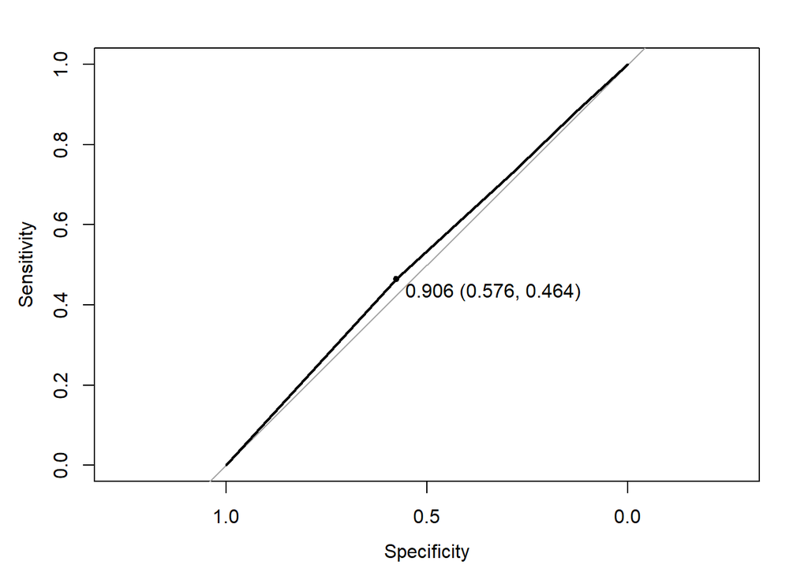

```r
plot.roc(Validation_Data$Personal.Loan,pred.prob[,1],print.thres="best")
```

Setting a threshold of 0.906 improves the model by decreasing sensitivity to 0.464 and improving specificity to 0.576. ```